# QMSS G5072 Homework 6

Stephanie Langeland

2017-10-24

# Working with Strings

### 1. Words in Ulysses

#### a) Words with `z`

Select all words that contain at least one `z`.

```r
library(stringr)
z_words <- str_subset(words$word,
                          "z")

head(z_words)
```

```
## [1] "razor"      "razorblade" "razor"      "razorblade" "gazing"
## [6] "gazed"
```

Among the z-words, tabulate how many `z`’s the words contain (i.e. how many words contain one `z`, two `z`’s etc.).

```r
z_words_tbl <- str_count(z_words,
                         "z")

table(z_words_tbl)
```

```
## z_words_tbl
##   1   2   3
## 909  81   1
```

Find the z-word(s) with z’s that are as far apart as possible (i.e. we are interested in the distance between two z’s in the word. That means the word could contain more than two z’s.).

```r
zz_words <- z_words[z_words_tbl == 2]
zz_words
```

```
##  [1] "puzzled"       "nuzzling"      "zmellz"        "gizzards"
##  [5] "puzzle"        "sizzling"      "sizzling"      "mazzoth"
##  [9] "buzz"          "embezzling"    "muzzle"        "puzzling"
## [13] "quizzing"      "zigzagging"    "blizzard"      "lizzie"
## [17] "lizzie"        "puzzle"        "fizz"          "buzzed"
## [21] "buzzed"        "buzz"          "buzz"          "puzzled"
## [25] "mezzo"         "lizzie"        "quizzer"       "grizzled"
## [29] "buzzing"       "whizzed"       "gizzards"      "buzz"
## [33] "intermezzo"    "razzle"        "puzzle"        "dazzling"
## [37] "muzzling"      "fizz"          "puzzle"        "buzz"
## [41] "pizzle"        "drizzling"     "huzzah"        "piazzetta"
## [45] "guzzling"      "winefizzling"  "ginsizzling"   "booseguzzling"
## [49] "muzzle"        "nozzle"        "nozzle"        "quizzing"
## [53] "quizzing"      "mazzoth"       "buzz"          "azazel"
## [57] "buzz"          "gizzard"       "buzz"          "buzz"
## [61] "nozzle"        "zigzag"        "drizzle"       "fizzing"
## [65] "buzzard"       "drizzle"       "zigzags"       "zigzag"
## [69] "fizz"          "dizzily"       "mezzo"         "mezzo"
## [73] "puzzled"       "nozzle"        "grizzled"      "puzzling"
## [77] "gizzard"       "piazzi"        "mezzanine"     "gizzard"
## [81] "embezzlement"
```

```r
zz_distance <- str_locate_all(zz_words,
                              "z")

zz_distance2 <- as.data.frame(zz_distance)

zz_distance2[ , 1:4]
```

```
##   start end start.1 end.1
## 1     3   3       3     3
## 2     4   4       4     4
```

```r
zz_words3 <- z_words[z_words_tbl == 3]
zz_words3
```

```
## [1] "százharminczbrojúgulyás"
```

```r
zz_distance3 <- str_locate_all(zz_words3,
                               "z")

zz_distance3
```

```
## [[1]]
##      start end
## [1,]     2   2
## [2,]     4   4
## [3,]    12  12
```

```r
zz_distance4 <- as.data.frame(zz_distance3)

zz_distance2[1, 163] <- 2
zz_distance2[2, 163] <- 4

colnames(zz_distance2)[163] <- "start.81"

zz_distance2[1, 164] <- 4
zz_distance2[2, 164] <- 12
colnames(zz_distance2)[164] <- "end.81"

zz_distance2[3, ] <- zz_distance2[2, ] - zz_distance2[1, ]

zz_lengths <- sort(
  unique(
    zz_distance2[3, ]
    ),
  decreasing = TRUE
  )

#zz_lengths

col_num <- which(zz_lengths > 1)

zz_lengths[ , col_num]
```

```
##   end.81 start.2 end.2 start.13 end.13 start.61 end.61 start.66 end.66
## 3      8       5     5        3      3        3      3        3      3
##   start.67 end.67 start.55 end.55 start.81
## 3        3      3        2      2        2
```

Words with more than 1 space between the `z`’s in descending order:

```r
zz_words3 ## `end.81` is actaully `zz_words3` because it was added later on
```

```
## [1] "százharminczbrojúgulyás"
```

```r
zz_words[3]
```

```
## [1] "zmellz"
```

```r
zz_words[14]
```

```
## [1] "zigzagging"
```

```r
zz_words[62]
```

```
## [1] "zigzag"
```

```r
zz_words[67]
```

```
## [1] "zigzags"
```

```r
zz_words[68]
```

```
## [1] "zigzag"
```

```r
zz_words[56]
```

```
## [1] "azazel"
```

```r
zz_words3 ## `start.81` is actaully `zz_words3` because it was added later on
```

```
## [1] "százharminczbrojúgulyás"
```

All other “z” words have one space between the `z`’s.

#### b) Vowels

How many words start and end with a vowel?

```r
vowels_st_end <- str_subset(words$word,
                   pattern = "^[aeiouAEIOU]+.[aeiouAEIOU]$")

length(vowels_st_end)
```

```
## [1] 1698
```

Are there words that start with two or more vowels?

```r
vowels_2_st <- str_subset(words$word,
                          pattern = "^[aeiouAEiou]{2,}")

head(vowels_2_st)
```

```
## [1] "air"  "out"  "air"  "oak"  "ouns" "aunt"
```

```r
length(vowels_2_st)
```

```
## [1] 2581
```

Find and display the word(s) with the most consecutive vowels.

- Top 6 words with the most consecutive vowels:

```r
str_subset(words$word,
             pattern = "[aeiouAEIOU]{10,}")
```

```
## [1] "steeeeeeeeeeeephen"           "iiiiiiiiiaaaaaaach"
## [3] "dooooooooooog"                "goooooooooood"
## [5] "frseeeeeeeeeeeeeeeeeeeefrong" "sooooooooooong"
```

#### c) English spelling

Empirically verify the rule [“i before e except after c”](https://en.wikipedia.org/wiki/I_before_E_except_after_C).

```r
new_string <- tolower(words$word)
```

Words that comply with the rule:

```r
comply <- str_subset(new_string,
         "(cei|[^c]ie)") ## "cei" or "ie" not preceded by "c"

head(comply)
```

```
## [1] "cried"    "quietly"  "friendly" "cried"    "quietly"  "cried"
```

Words that do not comply with the rule:

```r
non_compliance <- str_subset(new_string,
                             "(cie|[^c]ei)") ## "cie" or "ei" not preceded by "c"

head(non_compliance)
```

```
## [1] "dei"     "ancient" "seized"  "seeing"  "their"   "veiling"
```

### 2. Emergency Hospital Injuries

The file `emergency.csv` contains a random sample of 10,000 narratives of injuries treated in U.S. emergency departments. We will try to extract some structured data from these narratives.

#### a) Length of Narratives

Read in the data (use `read_csv` from the `readr` package).

```r
data_import <- "/Users/StephanieLangeland/Desktop/Columbia/Modern Data Structures/Langeland_Stephanie/hw06/emergency.csv"

library(readr)
data1 <- read_csv(data_import,
                  col_types = cols(
                    col_character()
                  ),
                  col_names = FALSE)

colnames(data1)[1] <- "description"

data1$nchar <- str_length(data1$description)
```

Find and display the longest and shortest description.

- The longest description has 143 characters, there are 66 descriptions of that length:

```r
longest <- max(data1$nchar)

longest_position <- which(data1$nchar == longest)

length(longest_position)
```

```
## [1] 66
```

```r
table(
  data1[longest_position, ]
)
```

```
##                                                                                                                                                  nchar
## description                                                                                                                                       143
##   ^64YOM LIFTING A CAR BATTERY OUT OF HIS CAR AND TWISTED AWKWARDLY AND N OW HAVING SEVERE PAIN DOWN LOWER BACK ADMIT FOR INTRACTABLE LUMBAR PAIN   1
##   10 YOM WAS PLAYING BASEBALL, WITH A FRIEND, & GOT HIT IN THE MOUTH BY A BASEBALL- TEETH ARE LOOSE, GUM BLEEDING.DX; DENTAL TRAUMA, LIP HEMATOMA   1
##   10YOM; PT WAS GETTING DRESSED IN FRONT OF THE HEATER WHEN HE BEGAN TO G ET A HEADACHE AND FELT SICK & PASSED OUT.  D: CARBON MONOXIDE POISONING   1
##   11 YOF WAS JUMPING ON THE BED, AT HOME, & FELL ONTO A PAIR OF SCISSORS, THEY WENT INTO HER CHEST.  DX: HEMOTHORAX SECONDARY TO PENETRAT. TRAUMA   1
##   116 YOM-@ SCHOOL PLAYING BASKETBALL-KNOCKED DOWN-FELL ON R SHOULDER & A NOTHER PLAYER STEPPED ON L CLAVICLE       DX  CONTUSION L SHOULDER POSS   1
##   12YOF FELL OFF OF A BENCH WHILE AT SCHOOL, THE BENCH FELL AND HIT HER L LEG AND THEN SHE FELL ONTO LEG PT HAS PAIN, DX CONTUSION TO L LOWER LEG   1
##   13YOM DID OUTDOOR WORKOUT X1 1/2 HRS, DEVELOEPD HEADACHE, TUNNEL VISION , THEN PLAYED FOOTBALL, WATCHING TV AFTER W/HEADACHE; MIGRAINE HEADACHE   1
##   14YOF PT DIABETIC, HAVING INTENSIVE VOLLEYBALL TRY OUTS LAST COUPLE WEE KS, STARTED VOMITNG, ELEVATED BLOOD SUGAR LAST NIGHT; VOMITING, HIGH BS   1
##   15YF ON BUS TO SOCCER GAME&NOTICED "FUNNY SMELL", AFTER BEING OFF BUS&P LACING SOCCER FOR 30-45MIN SHE&FELLOW RIDERS BECAME LTHARGIC/HA>CO EXPO   1
##   16YOF IN FRIEND'S CAR WHEN PUT ON LATEX GLOVES, REMOVED GLOVE & PUT THU MB IN MOUTH, DEVELOPED TONGUE NUMBNESS, LIP SWELLING; ALLERGIC REACTION   1
##   16YOM  PT'S L SHOULDER POPPED OUT FOR A MOMENT WHILE SWINGING BAT PLAYI NG BASEBALL YEST.  VERY SORE TODAY.  DX. DISLOCATED L INTERIOR SHOULDER   1
##   17 YO F SLIPPED AT POOL WHEN FEET WENT OUT IN FRONT OF HER LANDING ON B UTTOCKS. HIT HEAD ON POOL DECK. DX: CHI, NECK STRAIN, LOWER BACK STRAIN   1
##   17MOBM  MOM STATES CHILD WAS IN THE FLOOR AND SHE NOTED STRANGE SMELL T O BREATH, SMELLED OF FINGERNAIL POLISH REMOVER.  DX. INGESTION NON-ACET   1
##   17YOM WITH FINGER FX LAST WEEK, HAD SPLINT PLACED IN ED, DECIDED TO PLA Y FOOTBALL GAME REINJURING SAME FINGER, TRAINER PUT BACK IN PLACE;REINJ   1
##   19MOWF  PARENTS HOLDING PT.  DAD STATES SHE WAS SLIDING DOWN SLIDE, WEA RING SHOES & LEG GOT CAUGHT ON THE SLIDE AT PARK.  DX. FX L PROX TIBIA.   1
##   19YO HISP MALE AT HOME WAS SHOT IN R EYE WITH PAINTBALL GUN, MILD BLURR Y VISION & PAIN, DX EYE CONTUSION,MONOCULAR VISION LOSS TRAUMATIC HYPHE   1
##   1MOF COUGH/WHEEZE X2W OR SINCE BIRTH, POSS INHALED SMOKE 1.5WA WHEN ELE CTRIC STOVE CAUGHT FIRE @ HOME, FIRE ISOLATED 2 STOVE, FD?;COUGH/WHEEZE   1
##   20 YO M, RUNNING FROM POLICE AFTER AN ALLEGED HOME INVASION, JUMPED OVE R FENCES & FELL OFF ROOF DURING CHASE. DX:CHI, AC SEPARATION, ANKLE SPR   1
##   21 YOM LACERATION TO LT HAND REPORTS WAS OPENING UP A BOTTLE OF CHAMPAG NE W/A CORK OPENER WHEN THE CORK FLEW & BOTTLE BROKE.+LAC TO LT FINGER%   1
##   21MOF IN LIVING ROOM,FOUND W/BURN THUMB,OTTOMAN ON FIRE NEXT TO GAS FIR EPLACE NOT LIT,THINKS PUT CHRISTMAS TREE TWIG IN PILOT LIGHT;BURN NO FD   1
##   22YOM WAS LIGHTING PROPANE PIZZA OVEN ON FRI. WHEN HE WAS BURNED ON FAC E, CHEST, HAND. HAS BEEN TREATING AT HOME. ?FDA. NO DETAILS.  DX:BURNS.   1
##   24YOM  R HAND/R WRIST PAIN AFTER HITTING A WALL TODAY.  PER PT, WAS SHA DOW BOXING TODAY & ACCIDENTALLY HIT WALL.  DX. FX R 5TH METACARPAL BASE   1
##   26 YO F, C/O TENDER GROWTH ON HEAD,HAS HAD IT SINCE CHILDHOOD,BUT WAS A T HAIRDRESSER TODAY,ACCIDENTALLY SCRAPED W/ HAIRBRUSHADX SCALP ABRASION   1
##   26 YO M INJECTING MORPHINE INTO R ARM, DEVELOPED SWELLING AND USED RAZO R BLADE TO CUT OPEN AREA AND DRAIN, NOW PAINFUL DX R FOREARM CELLULITIS   1
```

[output cut: 42 more lines]

- The shortest description has 16 characters, there are 2 descriptions of that length:

```r
shortest <- min(data1$nchar)

shortest_position <- which(data1$nchar == shortest)

length(shortest_position)
```

```
## [1] 2
```

```r
data1[shortest_position, 1]
```

```
## # A tibble: 2 x 1
##   description
##   <chr>
## 1 ABR HIP ON FLOOR
## 2 INGESTION OF ***
```

#### b) Fractures

Find all narratives related to “fractures”. Try to include singular/plural/verb forms in your search.

```r
fractures_display <- str_subset(data1$description,
         pattern = "(fracture|fractured|fractures|fracturing|FRACTURE|FRACTURED|FRACTURES|FRACTURING)")

head(fractures_display)
```

```
## [1] "10 MO F FELL OUT OF SHOPPING CART;DX FRACTURED SKULL"
## [2] "8YOF FRACTURED FINGER FELL OFF HER BIKE"
## [3] "41YO HISP MALE POKED R INDEX FINGER WITH A SCREWDRIVER DX CLOSED FRACTURE OF HAND, FELON"
## [4] "5 YR M FELL OFF FENCE;DX FRACTURED ELBOW"
## [5] "FELL AND INJURED R ANKLE AT SKATE RINK   FRACTURE R ANKLE 30YOM"
## [6] "13YOM FOUND DOWN WHILE SNOWBOARDING, UNWITNESSED TRAUMA, PT AMNESTIC, D X HEAD INJURY, PELVIC FRACTURE"
```

How many fracture narratives can you find?

```r
data1$fractures <- str_count(data1$description,
         pattern = "(fracture|fractured|fractures|fracturing|FRACTURE|FRACTURED|FRACTURES|FRACTURING)")

frac_narr_position <- which(data1$fractures > 0)

length(frac_narr_position)
```

```
## [1] 524
```

- There are 524 fracture-related narratives.

#### c) Body Parts

Among the fracture narratives, try to identify the body parts that are fractured (*Note*: Don’t go overboard. A selection of parts is sufficient.).

The selection/sample of body parts to be used for this exercise is noted below:

```r
fracture_data <- subset(data1,
                        subset = fractures > 0)

fracture_data$description <- tolower(fracture_data$description)

fracture_data$all_parts <- str_extract_all(fracture_data$description,
         "arm|arms|leg|legs|knee|knees|ankle|ankles|wrist|wrists|head|face|elbow|elbows|shoulder|shoulders|hand|hands|toe|toes|finger|fingers|hip|hips|foot|feet|nose|clavicle|neck|rib|ribs|thumb|thumbs")

fracture_data$all_parts <- str_replace_all(fracture_data$all_parts,
                                           '"',
                                           "")

fracture_data$all_parts <- str_replace_all(fracture_data$all_parts,
                                           "^c\\(",
                                           "")

fracture_data$all_parts <- str_replace_all(fracture_data$all_parts,
                                           "\\)",
                                           "")

fracture_data$all_parts <- str_replace_all(fracture_data$all_parts,
                                           "character\\(0",
                                           "")

ncol(fracture_data)
```

```
## [1] 4
```

```r
fracture_data[ ,5:8] <- str_split(fracture_data$all_parts,
                                  ",",
                                  simplify = TRUE)

fracture_data$n_parts <- str_count(fracture_data$all_parts,
                                       ",") ## number of body parts in narrative

colnames(fracture_data)[5] <- "part1"
colnames(fracture_data)[6] <- "part2"
colnames(fracture_data)[7] <- "part3"
colnames(fracture_data)[8] <- "part4"
```

Make a histogram of fractured body parts (but make sure plural and singular are combined.)

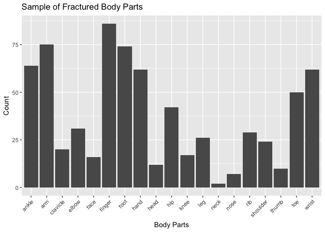

```r
## The only plural result was "feet", so replace it with "foot":
fracture_data$part1 <- ifelse(fracture_data$part1 == "feet",
                                      "foot",
                                      fracture_data$part1)

fracture_data$part2 <- ifelse(fracture_data$part2 == "feet",
                                      "foot",
                                      fracture_data$part2)

fracture_data$part3 <- ifelse(fracture_data$part3 == "feet",
                                      "foot",
                                      fracture_data$part3)

fracture_data$part4 <- ifelse(fracture_data$part4 == "feet",
                                      "foot",
                                      fracture_data$part4)

## Tabulate data for histogram:
library(QMSS)
tbl1 <- as.data.frame(Tab(fracture_data$part1))
tbl1$parts <- rownames(tbl1)

tbl2 <- as.data.frame(Tab(fracture_data$part2))
tbl2$parts <- rownames(tbl2)

tbl3 <- as.data.frame(Tab(fracture_data$part3))
tbl3$parts <- rownames(tbl3)

tbl4 <- as.data.frame(Tab(fracture_data$part4))
tbl4$parts <- rownames(tbl4)

tbl_parts <- cbind(tbl1,
                   tbl2)

tbl_parts$num <- tbl_parts[ , 1] + tbl_parts[ , 5]

tbl_parts <- tbl_parts[ , -c(1:7)]

tbl_parts <- tbl_parts[-1, ]

tbl_parts <- merge(tbl_parts,
                    tbl3,
                    all.x = TRUE)

tbl_parts$Count <- ifelse(is.na(tbl_parts$Count),
                          0,
                          tbl_parts$Count)

tbl_parts$num <- tbl_parts$num + tbl_parts$Count

tbl_parts <- tbl_parts[, -c(3:5)]

tbl_parts <- merge(tbl_parts,
                    tbl4,
                    all.x = TRUE)

tbl_parts$Count <- ifelse(is.na(tbl_parts$Count),
                          0,
                          tbl_parts$Count)

tbl_parts$num <- tbl_parts$num + tbl_parts$Count

tbl_parts <- tbl_parts[, -c(3:5)]



library(ggplot2)

ggplot(data = tbl_parts,
       aes(x = parts,
           y = num)) +
  geom_bar(stat = "identity") +
  theme(
    axis.text.x = element_text(angle = 45, hjust = 1)
    ) +
  xlab("Body Parts") +
  ylab("Count") +
  ggtitle("Sample of Fractured Body Parts")
```

#### d) Age and Gender

Let’s try to extract age and gender. In a number of narratives you may have noticed a pattern:

- “**75 YOM**, FELL DOWN STAIRS, FRACTURE LEG”: A 75 year old male.
- “**21MOF** FINGER SHUT IN WINDOW AT HOME;NAILBED INJURY: A 21 month-old female child.
- “DX:AVULSION OF SKIN-**50YOF**-CUT THUMB WITH SCISSORS TONIGHT-OPENING A BOX”: A 50 year old female.
- “LEFT ELBOW CONTUSION,RT SHIN LAC.PT WAS ICE SKATING AND FELL.”: No information about age or gender.

You are generally looking for a pattern with a number (*age*), something to indicate the *units*, e.g. YO or YR for years old, or MO for months old, and a character that identifies the *gender*. So, I suggest to think of a pattern that combines these three parts.

Create variables for age and gender (make sure to convert months to years when necessary).

- There are also people who are days old.

```r
data1$description2 <- tolower(data1$description)

data1$description2 <- str_replace_all(data1$description2,
                                      " ",
                                      "") ## remove spaces

data1$description2 <- str_replace_all(data1$description2,
                                      '[[:punct:] ]+',
                                      "") ## remove punctuaton

data1$details1 <- str_extract(data1$description2,
                          "[0-9]?[0-9]?[0-9](y|yr|m|day|month|year)(old)(male|m|female|f)?")

data1$details1a <- str_extract(data1$description2,
                              "[0-9]?[0-9]?[0-9](y|yr|m|day|month|year)(o)(male|m|female|f)?")

data1$details1b <- str_extract(data1$description2,
                              "[0-9]?[0-9]?[0-9](y|yr|m|day|month|year)o?(male|m|female|f)?")

data1$details1c <- str_extract(data1$description2,
                              "[0-9]?[0-9]?[0-9](y|yr|m|day|month|year)old?(male|m|female|f)?")

data1$details1d <- str_extract(data1$description2,
                              "[0-9]?[0-9]?[0-9][yyr|mdaymonthyear][oold]?[malemfemalef]?")

data1$gender <- str_extract(data1$details1d,
                            "f$|m$")


data1$age_digit <- str_extract(data1$details1b,
                              "[0-9]{2,3}")

data1$age_unit <- str_extract(data1$details1d,
                         "(m|mo|month|y|d)")

typeof(data1$age_digit)
```

```
## [1] "character"
```

```r
data1$age_digit <- as.numeric(data1$age_digit)

data1$age <- data1$age_digit

data1$age <- ifelse(data1$age_unit == "m",
                   data1$age_digit / 12,
                   data1$age_digit) ## month(s) old: age in years

data1$age <- ifelse(data1$age_unit == "d",
                   data1$age_digit / 365,
                   data1$age) ## day(s) old: age in years

data1 <- within(data1, rm("age_unit")) ## remove this column
data1 <- within(data1, rm("age_digit")) ## remove this column

#summary(is.na(data1$gender))
#summary(is.na(data1$age))

data1[1:5, c(1, 10:11)]
```

```
## # A tibble: 5 x 3
##   description                                              gender    age
##   <chr>                                                    <chr>   <dbl>
## 1 10 MO F FELL OUT OF SHOPPING CART;DX FRACTURED SKULL     f       0.833
## 2 75YOF WITH LAC TO FINGER FROM METAL CAN                  f      75.0
## 3 8YOF FRACTURED FINGER FELL OFF HER BIKE                  f      NA
## 4 9 YOM TACKLED DURING FOOTBALL PRACTICE.  DX: CONCUSSION. m      NA
## 5 PT WAS HIT ON RT SIDE WHILE PLAYING FOOTBALL DX: CHI     <NA>   NA
```

How many men and women are in the data?

```r
sum(data1$gender == "m",
    na.rm = T) ## men
```

```
## [1] 4351
```

```r
sum(data1$gender == "f",
    na.rm = T) ## women
```

```
## [1] 3397
```

- There are 4,351 men and 3,397 women.

Provide a line graph of the number of injuries (y-axis) vs age (x-axis) disaggregated by gender.

- Assuming that each narrative is an injury that prompted an emergency room visit:

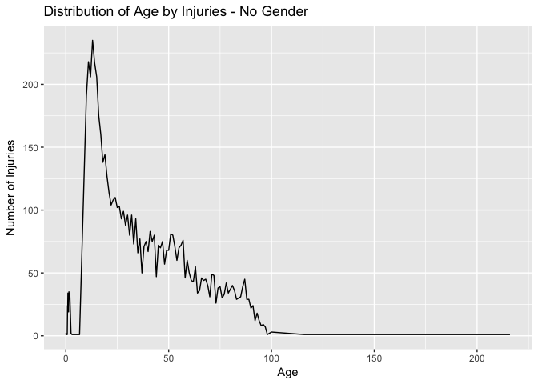

```r
ggplot(data = data1,
       aes(x = age)) +
  geom_line(stat = 'count') +
  xlab("Age") +
  ylab("Number of Injuries") +
  ggtitle("Distribution of Age by Injuries - No Gender")
```

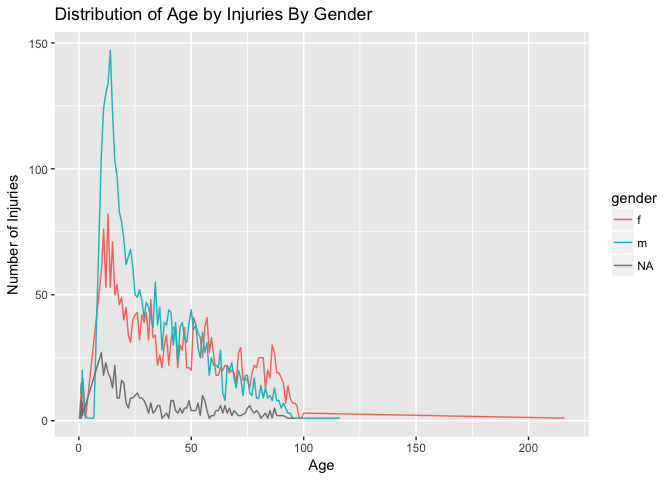

```r
ggplot(data = data1,
       aes(x = age,
           col = gender)) +
  geom_line(stat = 'count') +
  xlab("Age") +
  ylab("Number of Injuries") +
  ggtitle("Distribution of Age by Injuries By Gender")
```